## Tecnologias de sequenciamento

Há milhares de anos os humanos perceberam que as características físicas passam dos pais para os filhos. Em meados de 1850, Mendel, estudando ervilhas, demonstrou que essa transmissão dá-se por algo quantificável e que pode ser predito. É importante ressaltar que nos anos posteriores várias pesquisas sobre evolução e citologia estavam ocorrendo e já se tinha uma intuição de que essa informação genética deveria estar localizada em algum lugar dentro das células dos seres vivos.

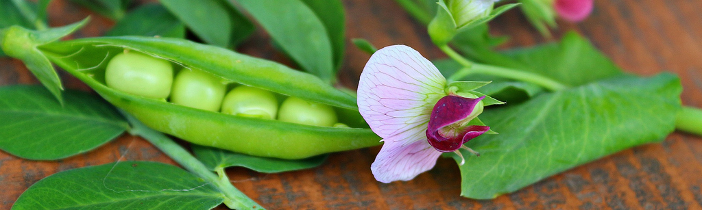

Friedrich Miescher isolou um ácido do núcleo das células brancas que posteriormente foi bastante estudado. Determinaram seus componentes. Seria aquela molécula a responsável transmissão da hereditariedade?

Erwin Chargaff advoga que sim e, a partir desse momento, mais energia é despendida pela comunidade científica em entender, não somente as regras de transmissão das características, mas também como as propriedades do DNA modelam os eventos biológicos em curso.

Um mundo fantasioso foi vislumbrado, onde o conhecimento da sequência completa do DNA dos indivíduos possibilitaria o controle total da Natureza. Sabemos contudo, que o fenótipo resultante da expressão dos genes depende de processos regulatórios extremamente complexos.

O presente artigo tem por objetivo apresentar como são determinados os componentes das sequências de DNA. Presume-se que o leitor tenha conhecimentos básicos de Bioquímica. Caso não tenha, recomendo um breve estudo sobre ácidos nucleicos e suas bases nitrogenadas.